# Introduction to Medical Statistics 2024 Exercises Class IV Normal distribution and the Confidence Intervals

## IV. Inference on the change in white cell count

The dataset bmData.csv contains selected variables from 300 patients with confirmed bacterial meningitis. They were randomized to either adjunctive dexamethasone therapy or placebo. In this exercise we study the change in CSF total white cell count between baseline and follow-up in the dexamethasone arm.

1. Have a look at [the description of the dataset](https://github.com/oucru-biostats/IntroductionToBiostatistics2024/blob/main/data/bmData_description.txt) and import the dataset bmData.csv into R with variable name *bmData* and use `tbl_summary` to summarise the dataset (except patId) by treatment group (variable `group`).

```r
library(gtsummary)
bmData <- read.csv('https://raw.githubusercontent.com/oucru-biostats/IntroductionToBiostatistics2024/main/data/bmData.csv') # HINT: change the function name to read a csv file (Exercise I)
tbl_summary(bmData[,-1],  # remove the first column, which is the patient ids
            by = group,   # do the summary by group
            missing_text = '(missing)')
```

| **Characteristic** | **dexamethasone** N = 143<sup>1</sup> | **placebo** N = 157<sup>1</sup> |
| --- | --- | --- |
| age | 43 (33, 58) | 42 (29, 52) |
| sex |  |  |
| F | 43 (30%) | 37 (24%) |
| M | 100 (70%) | 120 (76%) |
| gcs | 12 (9, 15) | 13 (10, 15) |
| paresis | 16 (11%) | 9 (5.7%) |
| op.csf | 20 (14, 35) | 20 (16, 28) |
| (missing) | 35 | 28 |
| wc.csf | 3,600 (1,000, 7,800) | 2,808 (1,175, 8,045) |
| (missing) | 0 | 1 |
| glu.csf | 19 (10, 36) | 20 (10, 37) |
| wc.csf.fup | 828 (249, 2,800) | 945 (459, 2,129) |
| (missing) | 9 | 13 |
| death.6mo | 9 (6.3%) | 22 (14%) |

<sup>1</sup> Median (Q1, Q3); n (%)

2. Create a dataset that restricts observations to the dexamethasone group (e.g. using the *subset* function; look at the examples in the help file for filter if you need to learn how to use it).
- Make a numerical summary of CSF total white cell count at each of the time points: *wc.csf* at baseline and *wc.csf.fup* at follow-up. What do you find regarding the distributions and value ranges?

**Answer** Both have skewed distributions with only values larger than zero

```r
bmData.dex <- subset(bmData,
                     group=="dexamethasone") # what group you want to see?
summary(bmData.dex$wc.csf)
```

```
   Min. 1st Qu.  Median    Mean 3rd Qu.    Max.
      1    1000    3600    6048    7790   48000
```

```r
summary(bmData.dex$wc.csf.fup)
```

```
   Min. 1st Qu.  Median    Mean 3rd Qu.    Max.    NA's
   16.0   250.8   827.5  3858.8  2757.5 84000.0       9
```

- Now make a histogram to describe the variation visually. Does CSF total white cell count at each of the time points approximately have a Normal distribution?
- If not: consider a suitable transformation of the variable and make the histograms again.

```r
# Load the packages first
library(ggplot2)
library(patchwork) # This is a nice package to align plots together
```

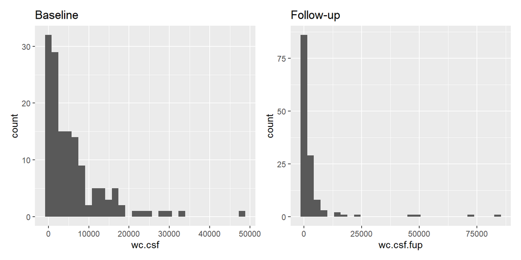

```r
plt.baseline <- ggplot(bmData.dex, aes(wc.csf)) +
  geom_histogram(boundary=0) +
  ggtitle("Baseline")
plt.fup      <- ggplot(bmData.dex, aes(wc.csf.fup)) +
  geom_histogram(boundary=0) +
  ggtitle("Follow-up")

## to show the two figures next to each other we simply use the "+" as defined in patchwork
plt.baseline + plt.fup
```

The plots clearly indicate a skewd distribution. For strictly positive variables with right skewness (i.e., having a wiggling tail on the right), a very effective transformation is the logarithm. We use the **log 10** transformation. We adjust the number of bin in the histogram to make it clearer.

Distribution on log-scale doesn’t look perfectly normal, but it’s better than the original scale.

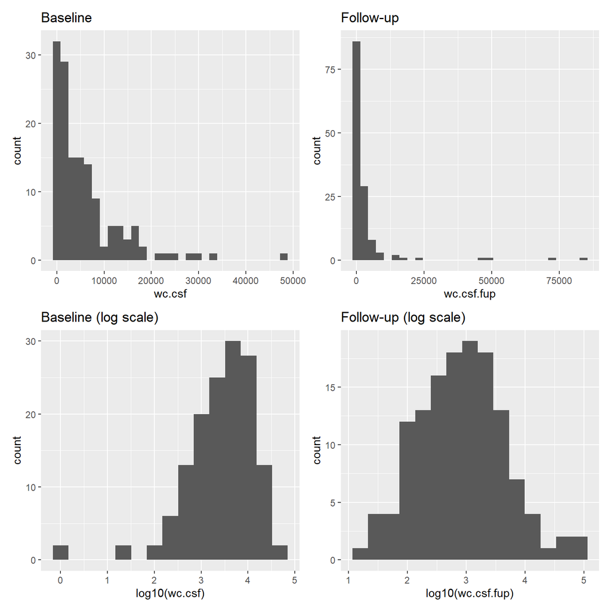

```r
plt.baseline.log <- ggplot(bmData.dex, aes(log10(wc.csf))) +
  geom_histogram(bins=15) +
  ggtitle("Baseline (log scale)")
plt.fup.log      <- ggplot(bmData.dex, aes(log10(wc.csf.fup))) +
  geom_histogram(bins=15) +
  ggtitle("Follow-up (log scale)")

## the "/" is defined in patchwork as a new line
(plt.baseline + plt.fup) / (plt.baseline.log + plt.fup.log)
```

3. We shall create a variable that contains the change in CSF total white cell count between baseline and follow-up. Do the same for the change in the transformed values. Have a look at the distribution of the difference (`diff.wc` and `diff.log.wc`), both for the original variable as well as for the transformed variable.

**Answer**:

- *If we plot baseline and follow-up values separately, their distributions are quite skewed*
- *If we plot the absolute difference of the original variable, the distribution is more symmetric (because of the substraction extreme values can occur in both directions) but there are many outliers.*
- *The distribution of the difference in log-values is closer to normal.*

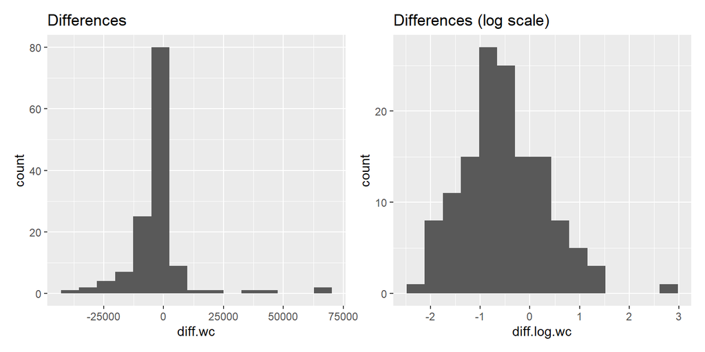

```r
# Original scale
bmData.dex$diff.wc <- bmData.dex$wc.csf.fup-bmData.dex$wc.csf

# Transformed scale
transform_fn <- log10 # ? what transform shall we take
bmData.dex$diff.log.wc <- transform_fn(bmData.dex$wc.csf.fup) - transform_fn(bmData.dex$wc.csf)

plt.diffwc <- ggplot(bmData.dex, aes(diff.wc)) +
  geom_histogram(bins=15) +
  ggtitle("Differences")
plt.difflogwc <- ggplot(bmData.dex, aes(diff.log.wc)) +
  geom_histogram(bins=15)  +
  ggtitle("Differences (log scale)")

plt.diffwc + plt.difflogwc
```

4. Compute the 95% confidence interval for the change in transformed value of CSF total white cell count, based on the quantiles of the Student’s t distribution. In $\textsf{R}$, the `t.test` function can be used. Is there a change in CSF total white cell count between baseline and follow-up? Compare the results with those if the change in the original values is studied.

**Answer**

```r
# t-test for the difference on original scale
t.test(bmData.dex$diff.wc)
```

```
    One Sample t-test

data:  bmData.dex$diff.wc
t = -2.1218, df = 133, p-value = 0.03571
alternative hypothesis: true mean is not equal to 0
95 percent confidence interval:
 -4535.491  -159.121
sample estimates:
mean of x
-2347.306
```

```r
# t-test for the difference on log10 scale
t.test(bmData.dex$diff.log.wc)
```

```
    One Sample t-test

data:  bmData.dex$diff.log.wc
t = -7.1351, df = 133, p-value = 5.623e-11
alternative hypothesis: true mean is not equal to 0
95 percent confidence interval:
 -0.662089 -0.374681
sample estimates:
mean of x
-0.518385
```

- You might also want to plot the comparison for insight. This is done via function `plotttest` in package `nhstplot`

```r
# Load the package first
library(nhstplot)
```

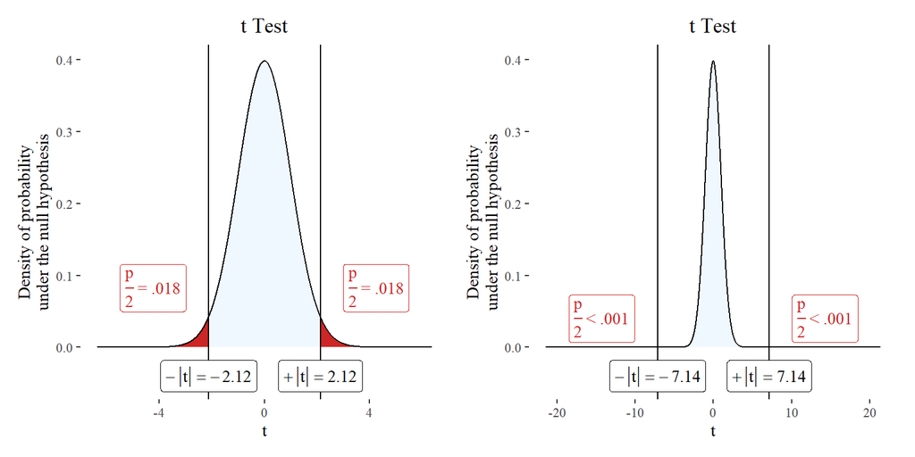

```r
# t-test on the original scale
orig.ttest.plot <- plotttest(t.test(bmData.dex$diff.wc))

# t-test on the log scale
log.ttest.plot <- plotttest(t.test(bmData.dex$diff.log.wc))

orig.ttest.plot + log.ttest.plot
```

5. Do the calculations to obtain the 95% confidence interval yourself and compare results with those from the `t.test` function. Use the function introduced in Exercise II. There are missing values, which we need to remove before we can apply the functions

```r
mean.diff <- mean(bmData.dex$diff.log.wc, na.rm=TRUE)
se.diff   <-
  sqrt(var(bmData.dex$diff.log.wc, na.rm=TRUE))/
  sqrt(143-9) # There are 9 missing values.
qstudent_t(p = c(0.025,0.975), # quantile to calculate
           df= 133,            # The number of degrees of freedom is N-1=133
           mu = mean.diff,
           sigma = se.diff)
```

```
[1] -0.662089 -0.374681
```